# Chamberlin N2O Analysis

Introducting packages, including gasanalyzR, my own personal set of functions that I’m storing for this type of analysis

```r
library(tidyverse)
library(broom)
library(gasanalyzR)
library(calecopal)
```

The data - including some preliminatry wrangling including dropping NAs, selecting only columns that we’ll use. Daily highs temperatures are from PRISM. Top rows of the data are shown.

```r
n2O_measurements = read.csv("../data/csv/N2O.csv") %>%
  mutate(date.analysis = lubridate::ymd(date.analysis),
         date.collection = lubridate::ymd(date.collection)) %>% drop_na(date.analysis)
n2o_standards = read.csv("../data/csv/N2O_standards.csv") %>% select(date, std.ppm, area) %>%
  drop_na() %>%
  mutate(date = lubridate::mdy(date))
buckets = read.csv("../data/csv/buckets.csv")
dailyhighs = read.csv("../data/csv/dailyhighs.csv")
head((n2O_measurements))
```

|  | date.collection | date.analysis | Component | treatment.type | site.id | bucket | syringe.id | area | Time | QC...Y.N. | PPM | field.temp..kelvin. | pressure..atm. | X | X.1 | X.2 | X.3 | X.4 | X.5 | X.6 | X.7 | X.8 | X.9 | X.10 | X.11 | X.12 |
| --- | --- | --- | --- | --- | --- | --- | --- | --- | --- | --- | --- | --- | --- | --- | --- | --- | --- | --- | --- | --- | --- | --- | --- | --- | --- | --- |
| 1 | 2019-03-13 | 2019-03-15 | N2O | t | 1 | 5 | 1001 | 191.8173 | 0 |  | N20 | 290.3722 | 1.002967 | NA | NA | NA | NA | NA | NA | NA | NA | NA | NA | NA | NA | NA |
| 2 | 2019-03-13 | 2019-03-15 | N2O | t | 1 | 5 | 1006 | 200.9948 | 60 |  |  | 290.3722 | 1.002967 | NA | NA | NA | NA | NA | NA | NA | NA | NA | NA | NA | NA | NA |
| 3 | 2019-03-13 | 2019-03-15 | N2O | t | 1 | 5 | 1011 | 197.5272 | 123 |  |  | 290.3722 | 1.002967 | NA | NA | NA | NA | NA | NA | NA | NA | NA | NA | NA | NA | NA |
| 4 | 2019-03-13 | 2019-03-15 | N2O | t | 1 | 9 | T191 | 189.1886 | 0 |  |  | 290.3722 | 1.002967 | NA | NA | NA | NA | NA | NA | NA | NA | NA | NA | NA | NA | NA |
| 5 | 2019-03-13 | 2019-03-15 | N2O | t | 1 | 9 | 1005 | 229.4420 | 61 |  |  | 290.3722 | 1.002967 | NA | NA | NA | NA | NA | NA | NA | NA | NA | NA | NA | NA | NA |
| 6 | 2019-03-13 | 2019-03-15 | N2O | t | 1 | 9 | 1010 | 253.8894 | 122 |  |  | 290.3722 | 1.002967 | NA | NA | NA | NA | NA | NA | NA | NA | NA | NA | NA | NA | NA |

```r
head(n2o_standards)
```

|  | date | std.ppm | area |
| --- | --- | --- | --- |
| 1 | 2019-03-15 | 0.0 | 0.0000 |
| 2 | 2019-03-15 | 0.0 | 0.0000 |
| 3 | 2019-03-15 | 0.1 | 45.9516 |
| 4 | 2019-03-15 | 0.1 | 44.4200 |
| 5 | 2019-03-15 | 0.1 | 45.3351 |
| 6 | 2019-03-15 | 1.0 | 389.0948 |

Create standard equations using standard.curve() from gasanalyzR

```r
standard_equations = standard.curve(n2o_standards, std_field = "std.ppm", peak_field = "area")
head(standard_equations)
```

|  | date | r.squared | intercept | std.error_int | p.value_int | slope | std.error_slope | p.value_slope |
| --- | --- | --- | --- | --- | --- | --- | --- | --- |
| 1 | 2019-01-15 | 0.9622916 | 0.006605540 | 0.036951451 | 0.86068520 | 0.0003017661 | 1.596511e-05 | 2.309296e-11 |
| 2 | 2019-03-15 | 0.9993815 | -0.010133363 | 0.004136683 | 0.02806352 | 0.0026525597 | 1.763660e-05 | 7.256994e-24 |
| 3 | 2019-04-02 | 0.9954217 | -0.001899642 | 0.011163885 | 0.86731914 | 0.0025530559 | 4.627502e-05 | 8.850192e-18 |
| 4 | 2019-04-05 | 0.9968896 | -0.009629463 | 0.009276626 | 0.31685070 | 0.0024771445 | 3.698026e-05 | 5.907530e-19 |
| 5 | 2019-04-19 | 0.9885142 | -0.007976217 | 0.017828877 | 0.66144723 | 0.0023318963 | 6.717921e-05 | 5.552095e-15 |
| 6 | 2019-04-25 | 0.9985024 | -0.009207245 | 0.006431598 | 0.17421355 | 0.0028895007 | 2.990759e-05 | 3.541388e-21 |

Wrangling daily high data

```r
high = dailyhighs %>% pivot_longer(cols = starts_with("high")) %>%
  mutate(date = str_remove(name, "high") %>% lubridate::ymd(),
         kelvin = (value + 273.15),
         Plot_ID = tolower(Plot_ID),
         Treatment = tolower(Treatment)) %>%
  select(date, Plot_ID, Treatment, kelvin) %>%
  rename(date.collection = date, site.id = Plot_ID, treatment.type = Treatment)
head(high)
```

| date.collection | site.id | treatment.type | kelvin |
| --- | --- | --- | --- |
| 2019-03-13 | 1 | t | 290.143 |
| 2019-04-01 | 1 | t | 299.266 |
| 2019-04-04 | 1 | t | 291.632 |
| 2019-04-18 | 1 | t | 299.180 |
| 2019-04-23 | 1 | t | 295.893 |
| 2019-05-07 | 1 | t | 292.338 |

Calculate ppm of N20 . We then add in data about bucket size and temperature

```r
a_s = merge(n2O_measurements, standard_equations, by.x = "date.analysis", by.y = "date") %>%
  mutate(concentration_ppm = (slope * area) + intercept)
a_s = merge(a_s, buckets, by = "bucket")
a_s$pressure..atm. = 1
a_s = merge(a_s, high, by = c("date.collection", "site.id", "treatment.type"), all.x = TRUE)
```

Converting ppm N20 back to grams N20 using the ideal gas law

```r
all_concentrations = a_s %>% mutate(moles = ((pressure..atm. * volume)/(0.082057 * kelvin)) * concentration_ppm/1000000,
                                                   grams_n2o = moles * 44.013)
```

Using our timepoints, our grams N2O measurements, and the bucket size, we can calculate the emission of N2O, in units of gN2O * m^-2 * hr^-1

```r
n_data = all_concentrations %>%
  select(date.collection, treatment.type, site.id, bucket, Time, grams_n2o, QC...Y.N.) %>%
  filter(QC...Y.N. != "Y") %>%
  mutate(timepoint = round(Time/60, 0))
t0 = filter(n_data, timepoint == 0)
t1 = filter(n_data, timepoint == 1)
t2 = filter(n_data, timepoint == 2)
h = merge(t0, t1, by = c("date.collection", "treatment.type", "site.id", "bucket"), all = T)
h = merge(h, t2, by = c("date.collection", "treatment.type", "site.id", "bucket"), all = T)
n_grams_time = h %>%
  select(date.collection, treatment.type, site.id, bucket, Time.x, grams_n2o.x, Time.y, grams_n2o.y, Time, grams_n2o) %>%
  filter(site.id != "alt") %>%
  drop_na() %>%
  rename(T0 = Time.x, T1 = Time.y, T2 = Time, T0n2o = grams_n2o.x, T1n2o = grams_n2o.y, T2n2o = grams_n2o) %>%
  mutate(change1 = ((T1n2o - T0n2o)/((T1 - T0)/60))/0.06334707,
         change2 = ((T2n2o - T1n2o)/((T2 - T1)/60))/0.06334707,
         change_mean = ((T2n2o - T0n2o)/((T2 - T0)/60))/0.06334707,
         changedif = change1 - change2) %>%
  pivot_longer(cols = starts_with("change"))
```

Seperating mean 2-hr measurements, single hour measurements, and difference between measurements from each hour

```r
means = n_grams_time %>% filter(name == "change_mean")
single = n_grams_time %>% filter(name != "change_mean") %>% filter(name != "changedif")
difs = n_grams_time%>% filter(name == "changedif")
```

```r
sums = means %>% group_by(date.collection, treatment.type, site.id) %>% summarise(mean = mean(value), n = n())
minmax = c(min(sums$mean, na.rm = T), max(sums$mean, na.rm = T))
```

A quick visualization of the distribution of our mean 2-hr emission measurements

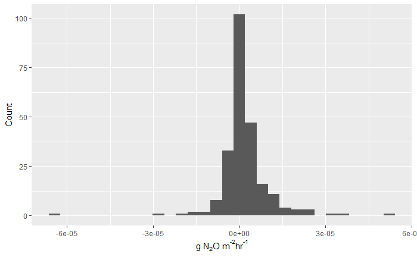

```r
ggplot(means, aes(x = value)) +
  geom_histogram() +
  xlab(expression("g N"[2]*"O m"^"-2" * "hr"^"-1")) +
  ylab("Count")
```

```r
NA
```

```r
# dif_from_zero = means %>%
#   drop_na(value) %>%
#   select(date.collection, site.id, treatment.type, value) %>%
#   group_by(date.collection, site.id, treatment.type) %>%
#   filter(n() >= 2) %>%
#   nest() %>%
  # map(data, ~t.test(data, mu = 0))
  # nest() #%>%
  # mutate(fit = map(data, ~t.test(.[["value"]], data = .)$p.value))
    #        results = map(fit, glance), results2 = map(fit, tidy)) %>%
    # unnest(results) %>%
    # select(-p.value, -statistic) %>%
    # unnest(results2) %>%
    # select(date, r.squared, term, estimate, std.error, p.value)
   #%>%
  # mutate(
  #   t_test = map2(A, B, ~{t.test(.x$value, .y$value) %>% tidy()}),
  #   A = map(A, nrow),
  #   B = map(B, nrow)
  # ) %>%
  # unnest()
```

Distribution of individual single-hour measurements

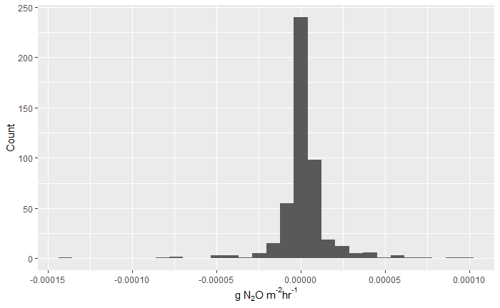

```r
ggplot(single, aes(x = value)) +
  geom_histogram() +
  xlab(expression("g N"[2]*"O m"^"-2" * "hr"^"-1")) +
  ylab("Count")
```

Plotting the distribution of the difference between the first hour and second hour. Values closer to zero indicate a constant rate of emission, values further from zero indicate a change in rate during the incubation.

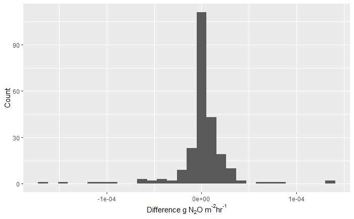

```r
ggplot(difs, aes(x = value)) +
  geom_histogram() +
  xlab(expression("Difference g N"[2]*"O m"^"-2" * "hr"^"-1")) +
  ylab("Count")
```

Calculated 2-hr mean emissions data from each date across the last year, separated by site, with treatments and control plots color-coded

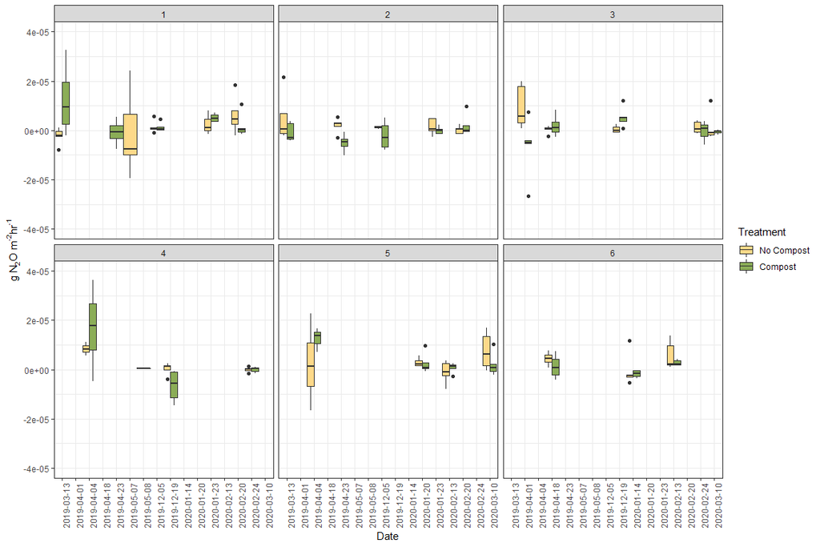

```r
ne = ggplot(means, aes(x = as.factor(date.collection), y = value, fill = treatment.type)) +
  geom_boxplot(position = "dodge", width = 1) +
  facet_wrap(.~site.id) +
  theme_bw() +
  theme(axis.text.x = element_text(angle = 90, hjust = 1)) +
  ylab(expression("g N"[2]*"O m"^"-2" * "hr"^"-1")) +
  ylim(-4e-5, 4e-5) +
  xlab("Date") +
  scale_fill_manual(name = "Treatment", values = cal_palette(name = "sierra2", n = 2, type = "discrete"), labels = c("No Compost", "Compost"))
# ggsave("../documents/figures/N2O_boxplot_by_site_3_5_20.png", plot = ne, device = "png", width = 12, height = 8)
ne
```